# Mice vs RGAIN

This section defines the GAIN algorithm. It includes the generator and discriminator architectures, their loss functions, and the training process.

```r
gain <- function(data, batch_size, hint_rate, alpha, iterations,learning) {

  # Define the loss function for the discriminator (D)
  D_loss <- function(y_true, y_pred) {
    M <- y_true[[1]]  # True mask matrix
    loss <- -k_mean(M * k_log(y_pred + 1e-8) + (1 - M) * k_log(1 - y_pred + 1e-8))
    return(loss)
  }

  # Define the loss function for the generator (G)
  # This consists of two parts:
  # - G_loss_temp: Encourages fooling the discriminator for missing values.
  # - MSE_loss: Enforces data consistency for observed values.
  G_loss <- function(y_true, y_pred) {
    M <- y_true[[1]]  # Mask matrix
    D_prob <- y_true[[2]]  # Output probabilities from the discriminator
    G_sample <- y_pred  # Generated data sample

    # Loss term for fooling the discriminator
    G_loss_temp <- -k_mean((1 - M) * k_log(D_prob + 1e-8))
    # Mean squared error (MSE) for observed data
    MSE_loss <- k_mean((M * X_mb - M * y_pred)^2) / k_mean(M)
    # Total generator loss
    G_loss <- G_loss_temp + alpha * MSE_loss
    return(G_loss)
  }

  # Generate the mask matrix indicating observed (1) and missing (0) values
  data_m <- 1 - is.na(data)

  # Store the dimensions of the data
  no <- nrow(data)
  dim <- ncol(data)

  # Normalize the data using min-max normalization
  norm_parameters <- parameters_norm(data)
  norm_data <- normalization(data, norm_parameters) %>%
    mutate(across(everything(), ~replace_na(., 0)))  # Replace NA with 0

  # Define the input layers for the GAN
  X <- layer_input(shape = c(dim))  # Data vector (input)
  M <- layer_input(shape = c(dim))  # Mask vector (observed/missing indicator)
  H <- layer_input(shape = c(dim))  # Hint vector (used to train discriminator)

  # Define the discriminator architecture
  inputs_D <- layer_concatenate(list(X, H))  # Combine data and hint vector

  D_output <- inputs_D %>%
    layer_dense(units = dim, activation = "relu",
                kernel_initializer = initializer_he_normal()) %>%
    layer_dense(units = dim, activation = "relu",
                kernel_initializer = initializer_he_normal()) %>%
    layer_dense(units = dim, activation = "sigmoid",  # Sigmoid for binary output
                kernel_initializer = initializer_he_normal())

  # Define the generator architecture
  inputs_G <- layer_concatenate(list(X, M))  # Combine data and mask vector

  G_output <- inputs_G %>%
    layer_dense(units = dim, activation = "relu",
                kernel_initializer = initializer_he_normal()) %>%
    layer_dense(units = dim, activation = "relu",
                kernel_initializer = initializer_he_normal()) %>%
    layer_dense(units = dim, activation = "sigmoid",  # Sigmoid for normalized output
                kernel_initializer = initializer_he_normal())

  # Create the discriminator and generator models
  discriminator <- keras_model(inputs = list(X, H), outputs = D_output)
  generator <- keras_model(inputs = list(X, M), outputs = G_output)

  # Compile the models with their respective loss functions
  discriminator %>% compile(optimizer = optimizer_adam(learning_rate = learning), loss = D_loss)
  generator %>% compile(optimizer = optimizer_adam(learning_rate = learning), loss = G_loss)

  # Initialize a progress bar for training
  pb <- tkProgressBar(title = "Progress", min = 0, max = iterations, width = 300)


  # See below
   D_loss_values <- c()
   G_loss_values <- c()



  # Training loop for the GAN
  for (i in 1:iterations) {
    # Sample a batch of data
    batch_idx <- sample(1:no, batch_size)
    X_mb <- as.matrix(norm_data[batch_idx, ])  # Batch of normalized data
    M_mb <- data_m[batch_idx, ]  # Corresponding mask for the batch

    # Generate random noise and hint matrix for the batch
    Z_mb <- runif(batch_size * dim, min = 0, max = 0.01) %>% matrix(nrow = batch_size, ncol = dim)
    H_mb_temp <- hint_matrix(hint_rate, batch_size, dim)
    H_mb <- M_mb * H_mb_temp  + 0.5*(1 - H_mb_temp)

    # Combine observed data with random noise for missing values
    X_mb <- M_mb * X_mb + (1 - M_mb) * Z_mb

    # Generate data using the generator
    G_sample <- generator %>% predict(list(X_mb, M_mb), verbose=0)

    # Combine real and generated data
    Hat_X <- X_mb * M_mb + G_sample * (1 - M_mb)

    # Generate discriminator probabilities
    D_prob <- discriminator %>% predict(list(Hat_X, H_mb), verbose=0)

    # Train the discriminator on real and generated data
    D_loss_value <- discriminator %>% train_on_batch(list(X_mb, H_mb), M_mb)

    # Train the generator to improve its performance
    G_loss_value <- generator %>% train_on_batch(list(X_mb, M_mb), list(M_mb, D_prob))

    # # Add losses to the list for monitoring
     D_loss_values <- c(D_loss_values, D_loss_value)
     G_loss_values <- c(G_loss_values, G_loss_value)



    # Update the progress bar
     if (i %% 100 == 0) cat("\rIteration", i,"\tGloss", G_loss_value, "\tDloss", D_loss_value)
    setTkProgressBar(pb, i, label = sprintf("Progress: %d%%", round(i / iterations * 100)))
  }

  # Close the progress bar after training
  close(pb)

  # Generate final imputed data
  Z_mb <- matrix(runif(no * dim, min = 0, max = 0.01), nrow = no, ncol = dim)
  X_mb <- data_m * norm_data + (1 - data_m) * Z_mb
  imputed_data <- generator %>% predict(list(as.matrix(X_mb), data_m), verbose=0)

  # Combine observed and generated data for the final result
  imputed_data <- data_m * norm_data + (1 - data_m) * imputed_data

  # Renormalize the imputed data to the original scale and round if necessary
  imputed_data <- renormalization(imputed_data, norm_parameters) %>%
    rounding(data)

  imputed <- list(data = imputed_data,
                  D_loss = D_loss_values,
                  G_loss = G_loss_values
                  )
  # Return the imputed dataset
  return(imputed)
}
```

This chunk defines the main function that:

- Introduces missing values into the dataset based on a specified missing rate.
- Applies the GAIN algorithm to impute missing values.
- Calculates and prints the RMSE.

```r
main_gain <- function(data, miss_rate = 0.2, batch_size = 128, hint_rate = 0.9, alpha = 100, iterations = 1000, learning = 0.001) {
  # Parameters:
  # data: The original dataset to process.
  # miss_rate: Proportion of missing values to introduce (default 20%).
  # batch_size: Number of samples in each training batch for the GAN.
  # hint_rate: Proportion of observed values used as hints for the discriminator.
  # alpha: Hyperparameter controlling the trade-off between adversarial loss and MSE loss in the generator.
  # iterations: Number of training iterations for the GAIN algorithm.

  # Get the number of rows and columns in the input dataset
  no <- nrow(data)  # Number of rows (observations)
  dim <- ncol(data) # Number of columns (features)

  # Create a mask matrix indicating observed and missing values
  # `missig` generates a matrix where each value is 1 (observed) with probability (1 - miss_rate),
  # and NA (missing) with probability `miss_rate`.
  mask <- missig(1 - miss_rate, no, dim)

  # Apply the mask to the original data to create a version with missing values
  # Observed values remain intact, while missing entries are set to NA.
  data_missing <- mask * data

  # Impute the missing values using the GAIN algorithm
  # This uses the `gain` function with the specified parameters.
  imputed <- gain(data_missing, batch_size, hint_rate, alpha, iterations,learning)

  # Compute the RMSE between the original and imputed data
  # RMSE is calculated only for the missing entries.
  rmse <- rmse_loss(data, imputed$data, mask)

  # Print the RMSE
  cat("\n RMSE:",rmse)

  # Prepare the data for plotting the convergence of the GAN losses
  # - `iteration`: A sequence of iteration numbers from 1 to `iterations`.
  # - `G_loss`: Generator loss values (from the GAIN algorithm).
  # - `D_loss`: Discriminator loss values (from the GAIN algorithm).
  plot_data <- data.frame(
    iteration = 1:iterations,
    G_loss = imputed$G_loss,
    D_loss = imputed$D_loss
  )

  # Plot the losses of the Generator and Discriminator over iterations
  plot <- ggplot(plot_data, aes(x = iteration)) +
    geom_line(aes(y = G_loss, color = "Generator Loss")) + # Plot the generator loss
    geom_line(aes(y = D_loss, color = "Discriminator Loss")) + # Plot the discriminator loss
    labs(
      title = "GAIN loss convergence", # Title of the plot
      x = "Iterations", # Label for x-axis
      y = "Loss", # Label for y-axis
      color = "Legend" # Legend title
    ) +
    theme_minimal()

  #Print the plot
  print(plot)

  # Return the imputed dataset
  return(list(imputed_data=imputed$data, mask=mask))
}
```

## Impute letter data

Apply the algorithm to the dataset letter, given by the authors of the GAIN paper (Yoon, Jordon, and Schaar 2018).

```r
letter <- read.csv("C:/Users/laura/Documents/GitHub/genimp/mice trial/letter.csv")

set.seed(123)
# Impute missing values in the dataset using the GAIN algorithm
imputed_letter <- main_gain(letter)
```

```
## Iteration 100    Gloss 6.714648  Dloss 0.6370627Iteration 200    Gloss 6.100953  Dloss 0.5667996Iteration 300    Gloss 4.400737  Dloss 0.6933264Iteration 400    Gloss 4.591547  Dloss 0.551992Iteration 500     Gloss 4.807518  Dloss 0.6680862Iteration 600    Gloss 4.687531  Dloss 0.413612Iteration …
##  RMSE: 0.1805898
```

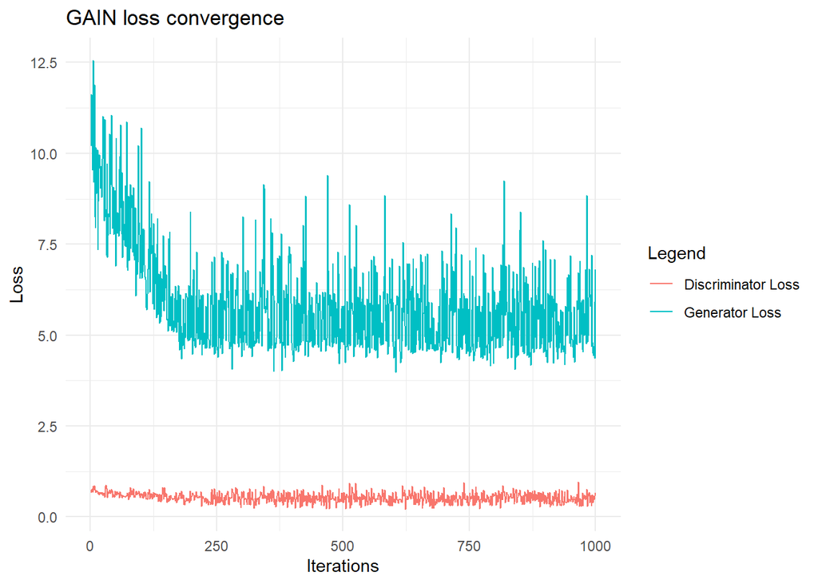

```r
#it took around 5 min to run this for 1000 iterations. The resulting RMSE is 0.180

#save the mask for the mice imputation
mask_letter<- imputed_letter$mask
```

RMSE of 0.180

## Impute generated data (1)

```r
set.seed(123)
g_data <- read.csv("gen_data.csv")

imputed_gen <- main_gain(g_data)
```

```
## Iteration 100    Gloss 28.7474   Dloss 0.6241692Iteration 200    Gloss 15.43013  Dloss 0.7283567Iteration 300    Gloss 23.18118  Dloss 0.5222789Iteration 400    Gloss 24.60726  Dloss 0.4962804Iteration 500    Gloss 21.945    Dloss 0.2703874Iteration 600    Gloss 21.80664  Dloss 0.2486113Iteration…
##  RMSE: 0.4096907
```

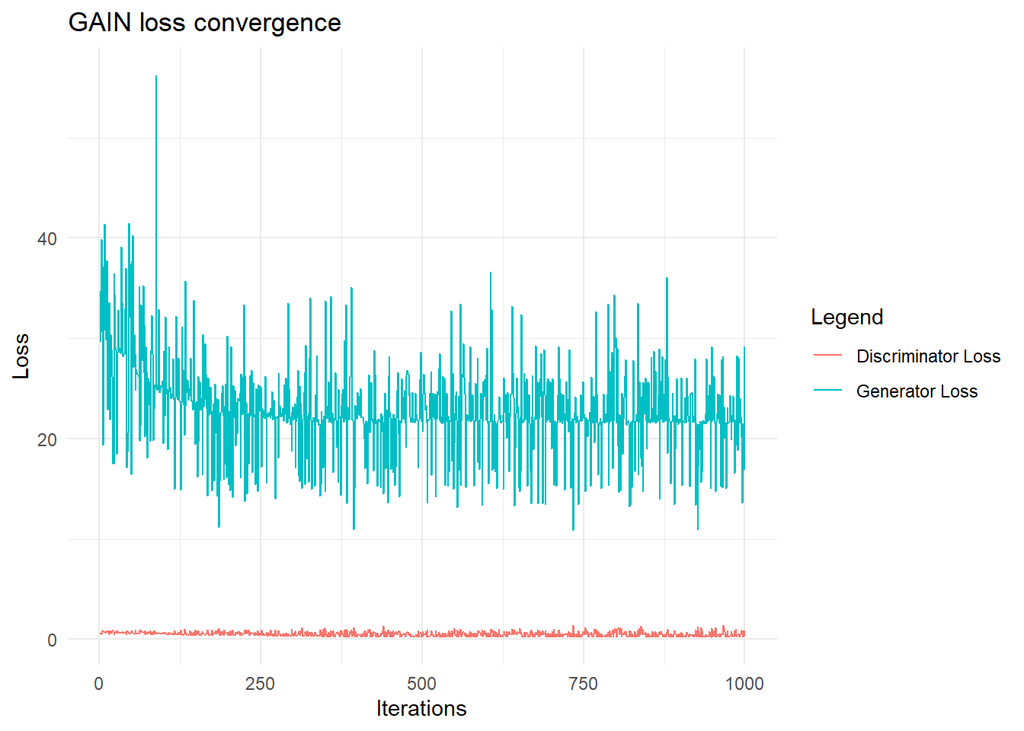

```r
#save the mask for the mice imputation
mask_gen <- imputed_gen$mask
```

## Imputing generated Data (2)

I could not make the data set with the categorical varibales run yet…

```r
#data with also categorical variables

#c_data <- read.csv("gen_catdata.csv")

#imputed_gc <- main_gain(c_data)
```

# Imputing Data with Mice

Impute letter data using mice (Buuren and Groothuis-Oudshoorn 2011) where most of the code is reused from mice_trial.Rmd.

```r
data_letter <- read.csv("C:/Users/laura/Documents/GitHub/genimp/mice trial/letter.csv")

# MinMax nomalization
normalization <- function(data, parameters = NULL) {
  # If no parameters are provided, calculate min and max for each column
  if (is.null(parameters)) {
    min_val <- apply(data, 2, min, na.rm = TRUE)
    max_val <- apply(data, 2, max, na.rm = TRUE)

    # Normalize data using min-max formula
    norm_data <- sweep(data, 2, min_val, "-")
    norm_data <- sweep(norm_data, 2, max_val - min_val, "/")

    # Return normalized data and the min/max parameters for future renormalization
    return(list(norm_data = norm_data, parameters = list(min_val = min_val, max_val = max_val)))
  } else {
    min_val <- parameters$min_val
    max_val <- parameters$max_val

    # Normalize using pre-calculated min and max values
    norm_data <- sweep(data, 2, min_val, "-")
    norm_data <- sweep(norm_data, 2, max_val - min_val, "/")

    return(norm_data)
  }
}

norm_l <- normalization(data_letter)
norm_data_letter <- norm_l$norm_data
parameters_letter <- norm_l$parameters  # parameters is a list, containing min_val and max

norms_letter <- normalization(data_letter, parameters_letter)
```

## Introduce missingness

```r
# Introduce missing values by using the same mask generated above
# Convert 0's in the mask to NA
mask_letter[mask_letter == 0] <- NA

data_m_letter <- norms_letter * mask_letter
```

## Imputing missing data

```r
set.seed(123)
library(mice)
mice_imputed_letter <- mice(data_m_letter, m = 1, maxit = 5)
imputed_m_letter <- complete(mice_imputed_letter)
```

## Calculate rmse

```r
# this function calculate the RMSE
rmse_loss <- function(ori_data, imputed_data, data_m, parameters = NULL){

  #I changed this part becuase I was running into a problem since i already normalized so with the previous code I renormalized, and replaced already exisiting parameters/incorrectly generated new ones

  # Ensure that the original data and imputed data are already normalized
  if (is.null(parameters)) {
    norm_result <- normalization(ori_data)
    parameters <- norm_result$parameters
  }
  # Calculate parameters only if not provided

  # Normalize the data if parameters are not passed (initial normalization)
  ori_data <- normalization(ori_data, parameters)
  imputed_data <- normalization(imputed_data, parameters)



  # Only for missing values
  nominator <- sum(((1-data_m) * ori_data - (1-data_m) * imputed_data)**2)
  denominator <- sum(1-data_m)

  rmse <- sqrt(nominator/denominator)

  return(rmse)
}
```

```r
# Calculate RMSE

mask_rmse_letter <- ifelse(is.na(mask_letter), 0, 1)  # Convert NA to 0, keeping valid entries as 1

# Calculate RMSE again
rmse_letter <- rmse_loss(norms_letter, imputed_m_letter, mask_rmse_letter, parameters_letter)
print(paste("RMSE:", rmse_letter))
```

```
## [1] "RMSE: 0.0102194790677255"
```

## mice for generated data

```r
gen_data <- read.csv("gen_data.csv")


norm_g <- normalization(gen_data)
norm_gen <- norm_g$norm_data
parameters_gen <- norm_g$parameters  # parameters is a list, containing min_val and max

norms_gen <- normalization(gen_data, parameters_gen)
```

## Introduce missingness

```r
# Introduce missing values by using the same mask generated above
# Convert 0's in the mask to NA
mask_gen[mask_gen ==0] <- NA

data_m_gen <- norms_gen * mask_gen
```

## Imputing missing data

```r
set.seed(123)

mice_imputed_gen<- mice(data_m_gen, m = 1, maxit = 5)
imputed_data_gen<- complete(mice_imputed_gen)
```

```r
# Calculate RMSE
mask_rmse_gen <- ifelse(is.na(mask_gen), 0, 1) # Convert NA to 0, keeping valid entries as 1

# Calculate RMSE again
rmse_gen <- rmse_loss(norms_gen, imputed_data_gen, mask_rmse_gen, parameters_gen)
print(paste("RMSE:", rmse_gen))
```

```
## [1] "RMSE: 0.0255944705694927"
```

# References

Buuren, Stef van, and Karin Groothuis-Oudshoorn. 2011. “Mice: Multivariate Imputation by Chained Equations in R.” *Journal of Statistical Software* 45 (December): 1–67. https://doi.org/10.18637/jss.v045.i03.

Yoon, Jinsung, James Jordon, and Mihaela Schaar. 2018. “GAIN: Missing Data Imputation Using Generative Adversarial Nets.” In *Proceedings of the 35th International Conference on Machine Learning*, 5689–98. PMLR.